# Web scraping & HTML tables

Friday, June 12, 2026

**NoteToday: Friday June 12**

**Before class**

- **Perusall Assignment**: [*DC* §16.3](https://psu.instructure.com/courses/2487468/assignments/18325375): HTML tables & web scraping

**Plan for today**

- Why scraping, and the ethics of doing it responsibly
- A 5-minute tour of HTML
- `rvest`: `read_html()`, CSS selectors, `html_text2()`, `html_attr()`
- The easy win: `html_table()`
- Cleaning what you scrape (footnotes, times, dates)
- In-class activity

**Helpful links**

- Syllabus · AI policy · Schedule · [*R4DS* Ch. 24](https://r4ds.hadley.nz/webscraping) · [*DC* Ch. 16](https://dtkaplan.github.io/DataComputingEbook/chap-scraping.html) · [rvest reference](https://rvest.tidyverse.org/reference)

# Why scrape?

## Every easy data format is alike

> *“Every easy data format is alike. Every difficult data format is difficult in its own way.”* - with apologies to Leo Tolstoy

So we’ve worked with easily accessible datasets like `penguins`, `flights`, or CSVs that can be quickly imported with `read_csv()`. But a lot of data is only available on **web pages** that are formatted for human eyes rather than `read_csv()`.

**Data scraping** is gathering data from sources that aren’t already in data-frame format; in our context, this is usually translating from the HTML a browser renders into a tidy data frame.

## When to scrape (and when not to)

Before you scrape, **always check for a friendlier door**:

1. **Is there a download link?**
2. **Is there an API?**
- Many sites (Spotify, the Census, GitHub) offer an [API](https://r4ds.hadley.nz/webscraping) that returns clean JSON. Often a CRAN package already wraps it (`tidycensus`, `spotifyr`, `gh`).
3. **Only then, scrape the HTML.**

Scraping is flexible but fragile. If a website administrator redesigns its HTML, your code will no longer work. It’s best to reserve web scraping for cases when no easier option is feasible.

# Good web-scraping citizens

## Ethical web-scraping

The rule of thumb from *R4DS*: you’re usually on safe ground if the data is

- **public**: you didn’t have to log in or click “I agree”,
- **non-personal**: not names, emails, locations of identifiable people, and
- **factual**: facts and data aren’t copyrightable (creative text and images are).

R4DS real-world cautionary example: 2016 researchers scraped ~70,000 **OkCupid** profiles. These are public, but deeply personal dating profiles. The researchers then released the profiles with no anonymization. It was widely condemned. *Public* does not mean *fair game* or *ethical*.

## Be a polite guest

A scraper can fire off thousands of requests in seconds. To a small server that may look like an attack.

- **Throttle**: pause between requests. Don’t hammer a server.
- **Cache**: never download the same page twice.
- **Identify yourself** and respect `robots.txt` and terms of service where you reasonably can.

The [`polite`](https://dmi3kno.github.io/polite/) package automates all of this for you, pausing, cauching, and checking `robots.txt` for you.

```r
# install.packages("polite")
library(polite)
session <- bow("https://www.example.com") # introduce yourself
result  <- scrape(session) # politely fetch
```

# Quick HTML tour

## What a web page really is

**HTML** (HyperText Markup Language) is the language behind every web page. Strip away the styling and it’s just nested text:

```html
<html>
<head>
  <title>Page title</title>
</head>
<body>
  <h1 id='first'>A heading</h1>
  <p>Some text &amp; <b>some bold text.</b></p>
  <img src='myimg.png' width='100' height='100'>
</body>
</html>
```

The whole page is a **tree** of nested elements. Scraping works precisely *because* most pages with data have a consistent, repeating structure.

## Anatomy of an element

- **Tags** come in pairs: `<p>` … `</p>`. The content lives in between.
- **Attributes** are `name='value'` pairs inside the start tag.
- Two attributes matter most for scraping:
  - **`id`**: a *unique* label for one element (`id='first'`)
  - **`class`**: a *reusable* label shared by many elements (`class='weight'`)

Designers use `id` and `class` to *style* the page. We hijack them to *find our data*.

## Example element

- Start Tag (<a … >): This opens the element and tells the browser where it begins.
- Attributes (href=‘/cats’, class=‘link’): These live inside the start tag and provide extra information or settings (like the destination URL or CSS styling classes).
- Contents (cute cats): This is the actual text, image, or nested element that gets displayed and affected by the tag.
- End Tag (): This closes the element, telling the browser where it stops.

## Useful tags to recognize

| Tag | Meaning |
| --- | --- |
| `<h1>`–`<h6>` | headings |
| `<p>` | paragraph |
| `<ul>` / `<ol>` / `<li>` | unordered / ordered list / list item |
| `<a href='...'>` | link (destination in the `href` attribute) |
| `<img src='...'>` | image (source in the `src` attribute) |
| `<b>` / `<i>` / `<span>` | bold / italic / inline container |
| `<table>` `<tr>` `<th>` `<td>` | table, row, header cell, data cell |

You don’t need to memorize HTML, but it’s useful to know enough to spot where your data is hiding. Google or the [MDN docs](https://developer.mozilla.org/) are great resources to help fill in any gaps.

# rvest

## The rvest workflow

[`rvest`](https://rvest.tidyverse.org/) (think “harvest”) is the tidyverse scraping package. It’s installed with the tidyverse but loaded separately:

```r
library(rvest)
```

Steps:

1. **`read_html(url)`**: download the page into R
2. **`html_elements(css)`**: select the pieces you want (a *CSS selector*)
3. **`html_element(css)`**: narrow to one piece per observation
4. **`html_text2()` / `html_attr()` / `html_table()`**: pull out the actual values

## Practice

`minimal_html()` is a function that allows us to hand write HTML. We’ll use it to learn, then use the same tools on real web pages.

```r
html <- minimal_html("
  <h1>This is a heading</h1>
  <p id='first'>This is a paragraph</p>
  <p class='important'>This is an important paragraph</p>
")
html
```

```
{html_document}
<html>
[1] <head>\n<meta http-equiv="Content-Type" content="text/html; charset=UTF-8 ...
[2] <body>\n<h1>This is a heading</h1>\n  <p id="first">This is a paragraph</ ...
```

Everything that follows works *identically* whether `html` came from `minimal_html()` or `read_html("https://...")`.

## CSS selectors: three you’ll use constantly

A **Cascading style sheets (CSS) selector** is a mini pattern language that provides a concise way of describing which HTML elements you want to extract from a web page.

| Selector | Selects | Read it as |
| --- | --- | --- |
| `p` | all `<p>` elements | “every paragraph” |
| `.important` | all elements with `class="important"` | “anything classed important” (dot = class) |
| `#first` | the element with `id="first"` | “the one with id first” (hash = id) |
| `p.important` | `<p>` elements that are *also* `class="important"` | combine them |
| `li b` | `<b>` *inside* an `<li>` | descendant (space) |

```r
html |> html_elements("p") # both paragraphs
```

```
{xml_nodeset (2)}
[1] <p id="first">This is a paragraph</p>
[2] <p class="important">This is an important paragraph</p>
```

```r
html |> html_elements(".important") # just the important one
```

```
{xml_nodeset (1)}
[1] <p class="important">This is an important paragraph</p>
```

```r
html |> html_element("#first") # the one with id="first"
```

```
{html_node}
<p id="first">
```

## element vs. elements (this trips everyone up)

- **`html_elements()`** (plural): returns *all* matches. Length depends on the page.
- **`html_element()`** (singular): returns *one match per input*, filling `NA` when nothing matches.

```r
html |> html_elements("b") # 0 matches -> empty
```

```
{xml_nodeset (0)}
```

```r
html |> html_element("b") # 0 matches -> NA (length preserved!)
```

```
{xml_missing}
<NA>
```

That `NA`-filling behavior keeps columns aligned.

## Why the distinction matters

```r
droids <- minimal_html("
  <ul>
    <li><b>C-3PO</b> is a <i>droid</i> that weighs <span class='weight'>167 kg</span></li>
    <li><b>R2-D2</b> is a <i>droid</i> that weighs <span class='weight'>96 kg</span></li>
    <li><b>Yoda</b> weighs <span class='weight'>66 kg</span></li>
    <li><b>R4-P17</b> is a <i>droid</i></li>
  </ul>
")
```

Grab the weights *directly* and you get **3** values for **4** characters and no way to know which one is missing:

```r
droids |> html_elements(".weight") |> html_text2()   # length 3 — misaligned!
```

```
[1] "167 kg" "96 kg"  "66 kg"
```

## Rows then columns

**Step 1.** Use `html_elements()` to grab one element *per observation* (each `<li>` is one character):

```r
characters <- droids |> html_elements("li")
length(characters) # 4 (one per character)
```

```
[1] 4
```

**Step 2.** Use `html_element()` *on each* to pull one value per observation. Missing weights become `NA`, so everything stays aligned:

```r
tibble(
  name = characters |> html_element("b") |> html_text2(),
  species = characters |> html_element("i") |> html_text2(),
  weight  = characters |> html_element(".weight") |> html_text2()
)
```

```
# A tibble: 4 × 3
  name   species weight
  <chr>  <chr>   <chr>
1 C-3PO  droid   167 kg
2 R2-D2  droid   96 kg
3 Yoda   <NA>    66 kg
4 R4-P17 droid   <NA>
```

**Tip**

`html_elements()` to find your *rows*, then `html_element()` to find each *column*.

## Pulling out the values

Selecting elements gets you HTML nodes. Two functions turn nodes into data:

**`html_text2()`**: the visible text (handles whitespace like a browser; prefer it over `html_text()`):

```r
droids |> html_elements("b") |> html_text2()
```

```
[1] "C-3PO"  "R2-D2"  "Yoda"   "R4-P17"
```

**`html_attr("name")`**: the value of an attribute, e.g. a link’s destination:

```r
links <- minimal_html("
  <p><a href='https://en.wikipedia.org/wiki/Cat'>cats</a></p>
  <p><a href='https://en.wikipedia.org/wiki/Dog'>dogs</a></p>
")
links |> html_elements("a") |> html_attr("href")
```

```
[1] "https://en.wikipedia.org/wiki/Cat" "https://en.wikipedia.org/wiki/Dog"
```

**Warning**

`html_attr()` **always returns a string**. `html_attr("width")` gives `"100"`, not `100`. Follow up with `parse_number()` / `as.integer()`.

# Tables

## html_table()

If your data is already in an HTML `<table>`, you’re in luck. `html_table()` reads it straight into a tibble, guessing column types as it goes.

```r
tbl <- minimal_html("
  <table>
    <tr><th>x</th>   <th>y</th></tr>
    <tr><td>1.5</td> <td>2.7</td></tr>
    <tr><td>4.9</td> <td>1.3</td></tr>
    <tr><td>7.2</td> <td>8.1</td></tr>
  </table>
")
tbl |> html_element("table") |> html_table()
```

```
# A tibble: 3 × 2
      x     y
  <dbl> <dbl>
1   1.5   2.7
2   4.9   1.3
3   7.2   8.1
```

`x` and `y` came back as `<dbl>` automatically. (Turn that off with `convert = FALSE` when the auto-guess misfires.)

## A real page: world record in the mile

The Wikipedia page on the [mile run world record progression](https://en.wikipedia.org/wiki/Mile_run_world_record_progression) holds **a dozen** tables. `html_elements("table")` grabs them all into a list:

```r
url <- "https://en.wikipedia.org/wiki/Mile_run_world_record_progression"

tables <- url |>
  read_html() |>
  html_elements("table") |>
  html_table()

length(tables)     # 12 tables on the page
record <- tables[[4]]   # the men's IAAF-era progression
```

[output not shown]

Double brackets `[[4]]` because `tables` is a **list** of data frames. (Note: Wikipedia changes frequently, so table *4* today may differ tomorrow; always be sure to look before you trust an index.)

# Cleaning scraped data

## Scraped data is usually dirty

Look closely at what we got:

- `Date` is `"31 May 1913[6]"`. Here, a footnote marker `[6]` is glued on.
- `Time` is `"4:14.4"`, which is a string, not a number we can plot or subtract.

Scraped values are **always character strings**, often with human-formatting baggage. The next step after scraping is almost always cleaning:

- `str_remove()` / `gsub()` + **regular expressions** to strip junk
- `parse_number()` for currency, percentages, stray units
- `lubridate` (`dmy()`, `mdy()`, …) for dates
- `as.duration(ms(...))` for times like `"4:14.4"`

## Stripping footnotes with a regex

We want to delete a bracketed footnote like `[6]` at the end of the date. A **regular expression** describes that pattern:

```r
record <- record |>
  mutate(Date = str_remove(Date, "\\[.\\]$"))
record$Date
```

```
[1] "31 May 1913"    "16 July 1915"   "23 August 1923" "4 October 1931"
[5] "15 July 1933"   "16 June 1934"
```

Decoding `"\\[.\\]$"`:

| Piece | Means |
| --- | --- |
| `\\[` `\\]` | a *literal* `[` and `]` (escaped — brackets are special) |
| `.` | any single character (here, the footnote digit) |
| `$` | anchored at the **end** of the string |

We’ll discuss regular expressions in more detail next week.

## Parsing dates and times

Once we have a clean date, we can use the `lubridate` package. These are `"4 October 1931"`-style to **day-month-year** to `dmy()`:

```r
record <- record |>
  mutate(
    Date = dmy(Date),
    seconds = as.numeric(as.duration(ms(Time))) # "4:14.4" -> 254.4 sec
  )
record |> select(Time, seconds, Date)
```

```
# A tibble: 6 × 3
  Time   seconds Date
  <chr>    <dbl> <date>
1 4:14.4    254. 1913-05-31
2 4:12.6    253. 1915-07-16
3 4:10.4    250. 1923-08-23
4 4:09.2    249. 1931-10-04
5 4:07.6    248. 1933-07-15
6 4:06.8    247. 1934-06-16
```

`ms()` reads `"minutes:seconds"`; `as.duration()` turns it into a real time span; `as.numeric()` gives plain seconds we can plot.

## Pay-off: a plot of progress

With clean `<date>` and numeric `seconds`, the record progression plots itself:

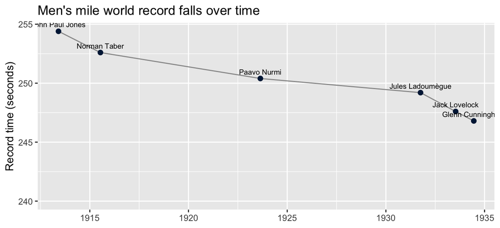

```r
ggplot(record, aes(x = Date, y = seconds)) +
  geom_line(color = "grey60") +
  geom_point(size = 2, color = "#001E44") +
  geom_text(aes(label = Athlete), vjust = -0.8, size = 2.6) +
  labs(
    title = "Men's mile world record falls over time",
    x = NULL, y = "Record time (seconds)"
  ) +
  expand_limits(y = 240)
```

From scattered HTML to a finished plot — the whole import-and-clean pipeline in one slide.

# Finding selectors

## How do I know *which* selector?

This is the genuinely hard part — and it’s normal to need trial and error. Three ways to discover the selector you need:

1. **Right-click then Inspect** in your browser. The developer tools highlight the exact HTML for whatever you clicked. Look at its `class` and `id`.
2. **[SelectorGadget](https://rvest.tidyverse.org/articles/selectorgadget.html)**: a point-and-click bookmarklet. Click what you *want* (turns green), click what you *don’t* (turns red), and it writes the selector for you.
3. **Copy as selector**: in DevTools, right-click an element → Copy → Copy selector.

You want a selector that’s **sensitive** (catches everything you want) *and* **specific** (catches nothing you don’t).

## Dynamic sites

Sometimes `html_elements()` returns *nothing* like what you see in the browser. Usually that means the page builds its content with **JavaScript** *after* loading.

`rvest` only downloads the raw HTML. It doesn’t run JavaScript. This means you should:

- Check whether the data is in the *raw* HTML (View Source, not Inspect).
- If it’s truly JS-rendered, you need a tool that drives a real browser: the [`chromote`](https://rvest.tidyverse.org/articles/) package runs Chrome in the background.
- Or, again: **look for an API first**. Dynamic pages are often fed by one.

# Activity

## In-class activity

Open `day19-activity.R` in RStudio and work through the parts in order.

- **Part 1**: HTML basics with `minimal_html()`: selectors, `element` vs `elements`, the alignment trap.
- **Part 2**: scrape a real Wikipedia table with `html_table()`, then clean dates and times and make a plot.
- **Part 3 (challenge)**: scrape *non-table* structured content (the rvest StarWars vignette) into a tidy tibble, and pull a link out of an attribute.

Activity file

## Wrap-up & looking ahead

**What we covered**

- Scrape responsibly: public, non-personal, factual; throttle & cache
- HTML is a tree of tags, with `class` and `id` attributes
- `rvest`: `read_html()` → `html_elements()` → `html_element()` → `html_text2()` / `html_attr()`
- The golden rule: **rows with `html_elements()`, columns with `html_element()`**
- `html_table()` for the easy wins
- Clean scraped strings with regex, `parse_number()`, `lubridate`, `as.duration(ms())`

**Upcoming**

- **Mon Jun 15:** writing your own **functions** (Week 5)
- **HW 4** due Mon Jun 15
- **Project Checkpoint 1** due Sun Jun 14

**Reach out**

Stuck? Office hours, or email me (cgc5478@psu.edu) or Xinyue (xpw5228@psu.edu).

**Reference**

Syllabus · AI policy · Schedule · [*R4DS* Ch. 24](https://r4ds.hadley.nz/webscraping) · [rvest reference](https://rvest.tidyverse.org/reference) · [SelectorGadget](https://rvest.tidyverse.org/articles/selectorgadget.html)